```python
import numpy as np
import matplotlib.pyplot as plt
import pandas as pd
import sys
import os
from scipy.stats import multivariate_normal
```

# Exercice 1

Q1

On tire $X$ selon une loi uniforme sur [0, 1]. On découpe l'intervalle [0, 1] en segments de taille $p_i$.

Si $X$ arrive dans l'intervalle $[i; i+1]$, on renvoie $x_i$

Q2

```python
def draw_along_P(probas, values):
    assert len(probas)==len(values)
    assert abs(np.sum(probas)-1) < 0.000001 # on vérifie que c'est bien une loi de probabié
    x=np.random.uniform(0,1)
    i = 0
    som_prob=0
    while x > som_prob:
        som_prob+=probas[i]
        i+=1
    return values[i-1]
```

Q3

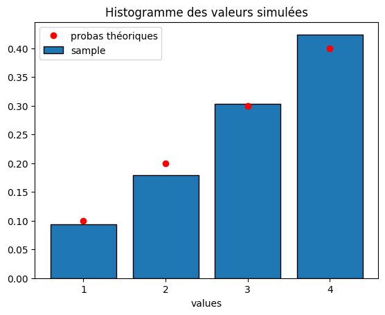

```python
probas=[0.1,0.2,0.3,0.4]
values=[1,2,3,4]
samples=[draw_along_P(probas, values) for i in range(1000)]
a, b=(np.histogram(samples, bins=4, range=(1,5)))
plt.bar([1, 2, 3, 4], a/1000, edgecolor='black', label='sample')
plt.plot([1, 2, 3, 4], probas, 'ro', label='probas théoriques')
plt.legend()
plt.xlabel('values')
plt.title('Histogramme des valeurs simulées')
plt.xticks([1, 2, 3, 4])
plt.show()
```

L'algorithme permet bien de sampler comme voulu

# Exercice 2

Q1

$\theta = (\mu_1, ... , \mu_m, \sigma_1, ..., \sigma_m, \alpha_1, ... \alpha_m)$

$\mathcal{L}(x_1, ..., x_n, \theta) = \Pi_{i=1}^n \sum_{j=1}^{m} \frac{1}{(2 \pi |\Sigma_j|)^{d/2}}exp((x_i-\mu)^T\Sigma_j^{-1}(x_i-\mu) )$

Q2

```python
probas=[0.3,0.3,0.4]
values=[0, 1, 2]
means_multi=[[1,1], [5, 5], [9, 9]]
covs=[[[1, 0.5], [0.5, 1]], [[1, 0.5], [0.5, 1]], [[1, 0.5], [0.5, 1]]]

samples_multi=[]
N=10000
for i in range(N):
    var_cachée=draw_along_P(probas, values) # dans quelle gaussienne est on ?
    samples_multi.append(np.random.multivariate_normal(means_multi[var_cachée], covs[var_cachée])) # on tire selon cette gaussienne
```

Q3

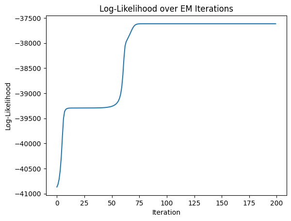

```python
def EM_multi(samples, m, max_iter=1000, epsilon=1e-3):
    log_likelihoods = []
    X=np.array(samples)
    n, d = X.shape
    alpha = np.ones(m) / m  # initialisation uniforme
    mu = np.random.rand(m, d)  # initialisation aléatoire
    sigma = np.array([np.eye(d) for _ in range(m)])   # initialisation identité
    for _ in range(max_iter):
        responsibilities = np.zeros((n, m))
        for j in range(m):
            responsibilities[:, j] = alpha[j] * multivariate_normal.pdf(X, mean=mu[j], cov=sigma[j])
        responsibilities /= responsibilities.sum(axis=1, keepdims=True) # normalisation
        n_j = responsibilities.sum(axis=0)  # nombre de points assignés à chaque cluster
        alpha = n_j / n # On en fait une loi de probabilité
        mu = np.dot(responsibilities.T, X) / n_j[:, np.newaxis]
        for j in range(m):
            diff = X - mu[j]
            sigma[j] = np.dot(responsibilities[:, j] * diff.T, diff) / n_j[j]
        log_likelihood = np.sum(np.log(np.sum([alpha[j] * multivariate_normal.pdf(X, mean=mu[j], cov=sigma[j])
                                            for j in range(m)], axis=0)))
        log_likelihoods.append(log_likelihood)

    return alpha, mu, sigma, log_likelihoods


al, mu, sig, log = EM_multi(samples_multi, 3, max_iter=200, epsilon=1e-4)

plt.plot(log)
plt.title("Log-Likelihood over EM Iterations")
plt.xlabel("Iteration")
plt.ylabel("Log-Likelihood")
plt.show()
```

```python
print('means: ')
print()
print('mean théorique : ')
print(means_multi)
print('mean estimé : ')
print(mu)
print()
print()
print('covs: ')
print()
print('cov théorique : ')
print(covs)
print('cov estimée : ')
print(sig)
print()
print()
print('probas: ')
print()
print('probas théorique : ')
print(probas)
print('probas estimée : ')
print(al)
```

[output not shown]

Q4

Q5

```python
df=pd.read_csv('./data/WPP2024_Demographic_Indicators_Medium.csv').dropna()
```

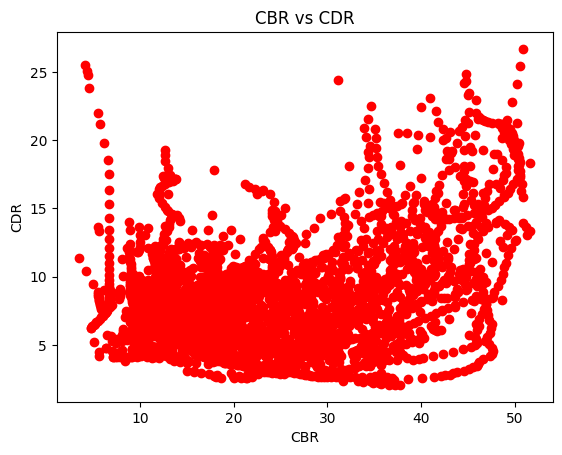

```python
df= df[['CBR', 'CDR']]
cbr=df['CBR'].values
cdr=df['CDR'].values
plt.plot(cbr, cdr, 'ro')
plt.xlabel('CBR')
plt.ylabel('CDR')
plt.title('CBR vs CDR')
```

Il semble qu'il y a plusieurs pôles de points, une mixture gaussienne serait donc pertinente.

Q6

```python
X=np.array([cbr, cdr]).T
X=(X-X.mean(axis=0))/X.std(axis=0) # renormalisation
```

```python
def compute_bic(loglik,complexite,nombre_de_points ):
    return loglik + 0.5*np.log(nombre_de_points)*complexite

def complexite_melange_gaussien(k, d): # 1 gaussienne = mu(taille d), sigma (taille d*d), alpha (taille 1), mais le dernier alpha est déterminé par les k-1 précédents
    return (k-1)+k*d+k*d*(d+1)/2
```

```python
all_bics=[]
for i in range(10): # on moyenne sur 10 calculs de la courbe de bic pour éviter les fluctuations et bien identifier le minimum
    bics=[]
    for m in range(1, 15):
        al, mu, sig, log  = EM_multi(X, m, max_iter=200, epsilon=1e-4)
        bics.append(compute_bic(-log[-1], complexite_melange_gaussien(m,2 ) -1, X.shape[0]))
    all_bics.append(bics)
```

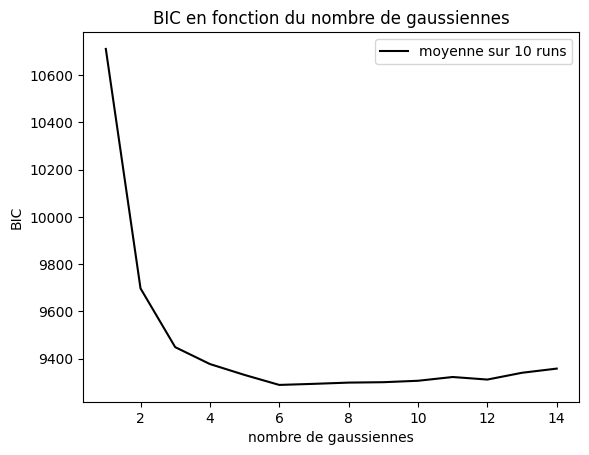

```python
plt.plot(range(1, 15), np.mean(np.array(all_bics), axis=0), 'k', label='moyenne sur 10 runs')
plt.xlabel('nombre de gaussiennes')
plt.ylabel('BIC')
plt.legend()
plt.title('BIC en fonction du nombre de gaussiennes')
plt.show()
```

On a donc $\hat{m} = 6 $

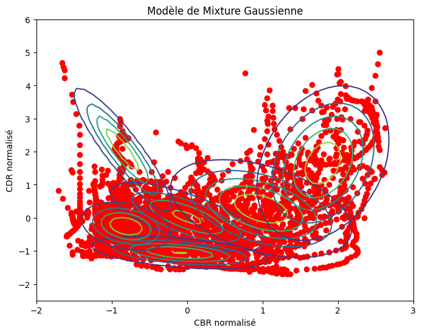

```python
al, mu, sig, log  = EM_multi(X, 6, max_iter=200, epsilon=1e-4)

x, y = np.meshgrid(np.linspace(-5, 5, 100), np.linspace(-5, 5, 100))
pos = np.dstack((x, y))
plt.figure(figsize=(8, 6))


plt.plot(X.T[0], X.T[1], 'ro')

for mean, cov in zip(mu, sig):
    rv = multivariate_normal(mean, cov)
    z = rv.pdf(pos)
    plt.contour(x, y, z, levels=5, cmap="viridis")
plt.xlim(-2, 3)
plt.ylim(-2.5, 6)
plt.title('Modèle de Mixture Gaussienne')
plt.xlabel('CBR normalisé')
plt.ylabel('CDR normalisé')
plt.show()
```

# Exercice 3

```python
def sample_along_q(): # tirage selon q
    sample= np.random.normal(0.8, 1.5)
    return sample

def q(x): # densité q
    return 1/np.sqrt(2*np.pi*1.5**2)*np.exp(-0.5*(x-0.8)**2/1.5**2)

def p(x): # densité p
    if x <0:
        return 0
    else :
        return (x ** (1.65-1) * np.exp(-x**2/2))/1.007368  # pour avoir une densité normalisée. On a calculé le facteur de normalisation en intégrant numériquement la densité sur R+

def f(x):
    if x <0:
        return 0
    else :
        return 2*np.sin(np.pi*x/1.5)

N=1000
samples=np.array([sample_along_q() for _ in range(N)])
print('on estime l espérance à ', np.mean(np.array([f(sample)*p(sample)/q(sample) for sample in samples])))
```

```
on estime l espérance à  0.8308842362132307
```

La valeur estimée de l'espérance est de 0.83

Q2

Pour $N \in [10, 100, 1000, 10 000]$, on lance 100 estimations de l'espérance, ce qui permet d'avoir accès à une valeur de la moyenne et de la variance des estimateurs. Ils sont visualisés sur le graphe ci-dessous.

```python
all_estimates=[]
all_importances=[]
for i in range(1, 5):
    N=10**i
    estimates=[]
    importances=[]
    for j in range(100):
        samples=np.array([sample_along_q() for _ in range(N)])
        estimates.append(np.mean(np.array([f(sample)*p(sample)/q(sample) for sample in samples])))
        importances.append(np.mean(np.array([p(sample)/q(sample) for sample in samples])))
    all_importances.append(importances)

    all_estimates.append(estimates)
```

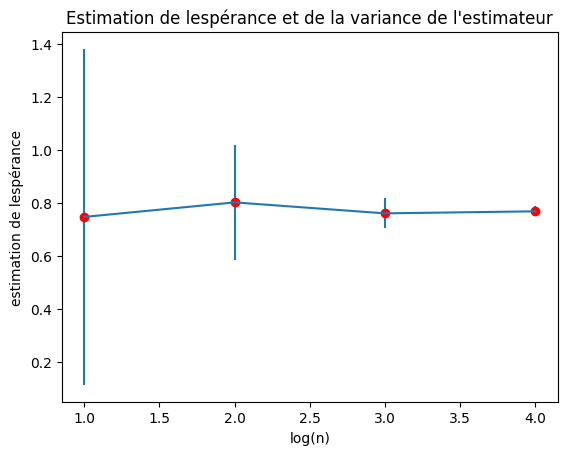

```python
plt.errorbar([1, 2, 3, 4],[np.mean(all_estimates[i]) for i in range(len(all_estimates))], yerr= [np.std(all_estimates[i]) for i in range(len(all_estimates))])
plt.plot([1, 2, 3, 4], [np.mean(all_estimates[i]) for i in range(len(all_estimates))], 'ro')
plt.ylabel('estimation de lespérance')
plt.xlabel('log(n)')
plt.title("Estimation de lespérance et de la variance de l'estimateur")
plt.show()
```

Comme attendu, les estimateurs ont la même moyenne (ils sont non biaisés), et la variance diminue avec N

Q3

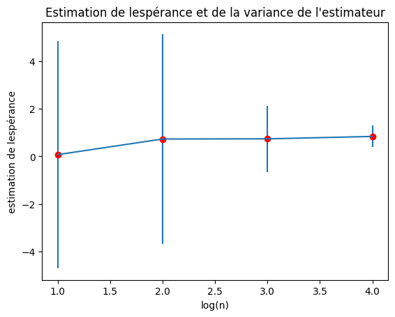

```python
def q_shifted(x): # changement de moyenne
    return 1/np.sqrt(2*np.pi*1.5**2)*np.exp(-0.5*(x-6)**2/1.5**2)

def sample_along_q_shifted(): # tirages selon q
    sample= np.random.normal(6, 1.5)
    return sample

all_estimates_shift=[]
all_importances_shift=[]
for i in range(1, 5):
    N=10**i
    estimates=[]
    importances=[]
    for j in range(100):
        samples=np.array([sample_along_q_shifted() for _ in range(N)])
        estimates.append(np.mean(np.array([f(sample)*p(sample)/q_shifted(sample) for sample in samples])))
        importances.append(np.mean(np.array([p(sample)/q_shifted(sample) for sample in samples])))
    all_estimates_shift.append(estimates)
    all_importances_shift.append(importances)


plt.errorbar([1, 2, 3, 4],[np.mean(all_estimates_shift[i]) for i in range(len(all_estimates_shift))], yerr= [np.std(all_estimates_shift[i]) for i in range(len(all_estimates_shift))])
plt.plot([1, 2, 3, 4], [np.mean(all_estimates_shift[i]) for i in range(len(all_estimates_shift))], 'ro')
plt.ylabel('estimation de lespérance')
plt.xlabel('log(n)')
plt.title("Estimation de lespérance et de la variance de l'estimateur")
plt.show()
```

Quand les distributions ne se recoupent pas, les estimateurs sont bien moins bons

On va maintenant comparer les importances, en regardant leur distribution pour q shifté et non shifté.

```python
importances=[]
importances_shifted=[]
for i in range(2, 6):
    N=10**i
    samples=np.array([sample_along_q_shifted() for _ in range(N)])
    importances_shifted.append((np.array([p(sample)/q_shifted(sample) for sample in samples])))
    samples=np.array([sample_along_q() for _ in range(N)])
    importances.append((np.array([p(sample)/q(sample) for sample in samples])))
```

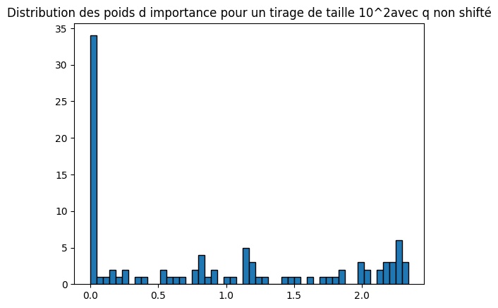

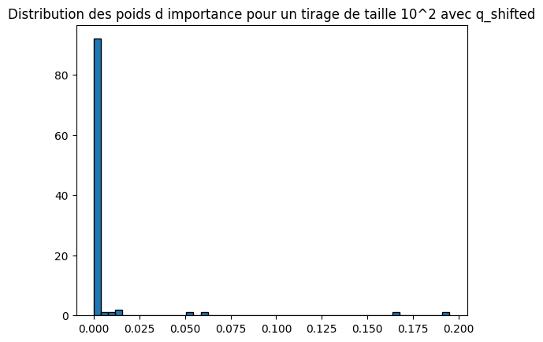

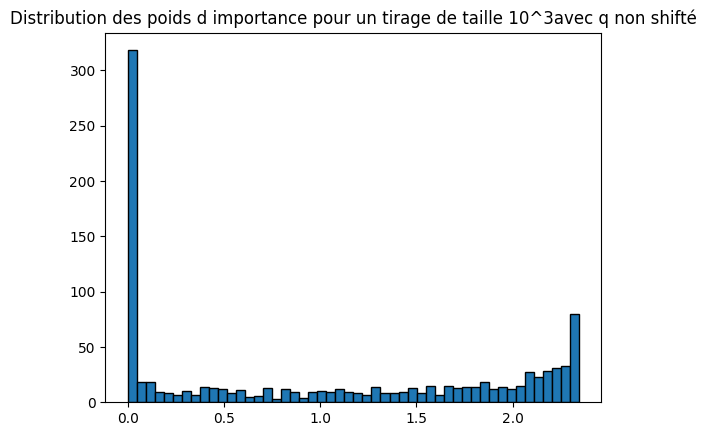

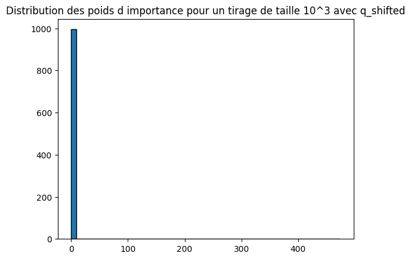

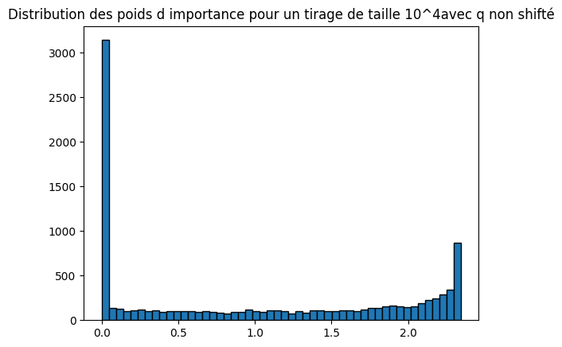

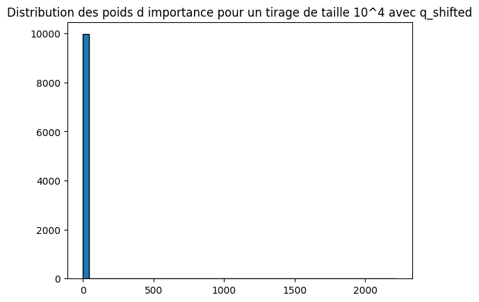

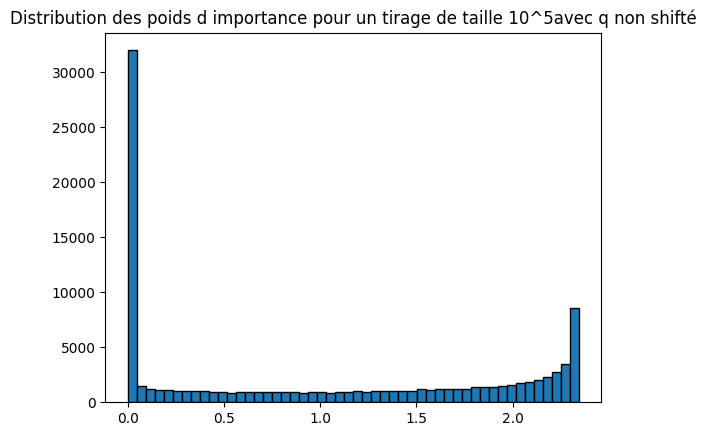

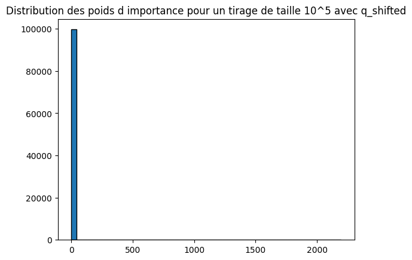

```python
for i in range(len(importances)):
    plt.hist(importances[i], bins=50, edgecolor='black')
    plt.title('Distribution des poids d importance pour un tirage de taille 10^'+str(i+2)+'avec q non shifté')
    plt.show()
    plt.hist(importances_shifted[i], bins=50, edgecolor='black')
    plt.title('Distribution des poids d importance pour un tirage de taille 10^'+str(i+2)+' avec q_shifted')
    plt.show()
```

On observe que la distribution des poids d'importance est beaucoup plus concentrée en zéro quand les probabilités ne se recouvrent pas. En effet, comme on tire selon $q$, $X_i$ atterit dans une zone ou p est très faible, et donc $\frac{p(X_i)}{q(X_i)}$ est très proche de 0.

Q4

Il s'agit d'un algorithme EM approché, avec :

- Une étape pour calculer une approximation de l'intégrale, en utilisant pour cela une estimation par échantillonnage d'importance.
- Une étape pour mettre à jour les paramètres.

Soit : $\gamma_{ij} = \frac{\tilde{\omega}_i^{(0)} \mathcal{N}(x_i \mid \mu_j^{(0)}, \Sigma_j^{(0)})}{\sum_{l=1}^{M} \omega_l^{(0)} \mathcal{N}(x_i \mid \mu_l^{(0)}, \Sigma_l^{(0)})}$

Alors :

$\alpha_j^{(1)} = \frac{\sum_{1\le i \le n} \gamma_{ij}}{\sum_{1\le i \le n} \sum_{1\le l \le n} \gamma_{il}} $

$\mu_j^{(1)} = \frac{\sum_{1\le i \le n} \gamma_{ij} X_i^{(0)}}{\sum_{1\le i \le n} \gamma_{ij}}$

$\Sigma_j^{(1)} = \frac{\sum_{1\le i \le n} \gamma_{ij} (X_i^{(0)}-\mu_j^{(1)}) (X_i^{(0)}-\mu_j^{(1)})^T }{\sum_{1\le i \le n} \gamma_{ij}} $

Q5

```python
d_v=5
sigma_2_v=1
b_v=0.4
Sigma_v=np.eye(d_v)
mu_v=np.array([0, 0, 0, 0, 0])


def v(x):
    assert len(mu_v)==len(x)
    x_copy=np.copy(x)
    x_copy[1]=x[1]+b_v*(x[0]**2-sigma_2_v)
    return 1/np.sqrt((2*np.pi)**d_v*np.linalg.det(Sigma_v))*np.exp(-0.5*np.dot(np.dot((x_copy-mu_v), np.linalg.inv(Sigma_v)), (x_copy-mu_v)))

def v_2D(x,y): # dépendance seulement les deux premières composantes, le reste est une constante
    return v(np.array([x, y, 0, 0, 0]))
```

```python
def gaussian_mixture(x, mus, Sigmas, alphas): # proba d'observer x selon le mélange gaussien
    return np.sum([alphas[i]*multivariate_normal.pdf(x, mean=mus[i], cov=Sigmas[i]) for i in range(len(mus))])
```

```python
def draw_gm(alphas, mus, Sigmas, n_samples): # drawing along a gaussian mixture
    assert abs(np.sum(alphas)-1) < 0.000001
    samples=[]
    for i in range(n_samples):
        x=np.random.uniform(0,1)
        i = 0
        som_prob=0
        while x > som_prob:
            som_prob+=alphas[i]
            i+=1
        samples.append(np.random.multivariate_normal(mus[i-1], Sigmas[i-1]))
    return samples
```

```python
def adaptive_importance_sampling(n_max, d, m, n_samples):
    alphas=np.ones(m)/m
    mus=[np.zeros(d) for _ in range(m)]
    sigmas=[np.eye(d) for _ in range(m)]

    hidden_values = [draw_along_P(alphas, range(m)) for _ in range(n_samples)]
    for _ in range(n_max):

        samples=[np.random.multivariate_normal(mus[hidden_values[i]], sigmas[hidden_values[i]]) for i in range(n_samples)]
        # w_i = celle qu'on veut approximer / q_i = celle qu'on connait donc ici le gaussian mixture model
        w_i=np.array([v(samples[i])/gaussian_mixture(samples[i], mus, sigmas, alphas) for i in range(n_samples)])
        w_i=w_i/np.sum(w_i)
        hidden_values = [draw_along_P(alphas, range(m)) for _ in range(n_samples)] # cluster de gaussienne
        for i in range(m): # iteration selon les formules de Q4
            mus[i]=np.mean(np.array([samples[j] for j in range(n_samples) if hidden_values[j]==i]), axis=0)
            sigmas[i]=np.cov(np.array([samples[j] for j in range(n_samples) if hidden_values[j]==i]).T)
            alphas[i]=np.sum([hidden_values[j]==i for j in range(n_samples)])/n_samples


    return alphas, mus, sigmas
alphas, mus, sigmas = adaptive_importance_sampling(50, 5, 3, 500)
```

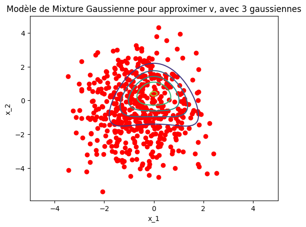

```python
n_samples=500
samples= draw_gm(alphas, mus, sigmas, n_samples)
samples_2D=[]
for i in range(n_samples):
    samples_2D.append([samples[i][0], samples[i][1]])
samples_2D=np.array(samples_2D)
plt.plot(samples_2D.T[0], samples_2D.T[1], 'ro')
x, y = np.meshgrid(np.linspace(-5, 5, 100), np.linspace(-5, 5, 100))
pos = np.dstack((x, y))
z = np.array([[v_2D(x[i][j], y[i][j]) for j in range(100)] for i in range(100)])
plt.contour(x, y, z, levels=5, cmap="viridis")

plt.title('Modèle de Mixture Gaussienne pour approximer v, avec 3 gaussiennes')
plt.xlabel('x_1')
plt.ylabel('x_2')
plt.show()
```